# **Project 3**, APS1070 Winter 2023

# Part 4: SVD [2 Marks]

Modify your code in part 3 to use SVD instead of PCA for extracting the eigenvectors. **[1]**

Ans: see cell #10

Explain if standardization or covariance computation is required for this part. Repeat part 3 and compare your PCA and SVD results. Write a function to make this comparison **[0.5]**, and comment on the results. **[0.5]**.

Ans:Standardization is needed since the svd is fitted on standardized data and we need to compute the reconstruction for the standardized time-series first, and then scale it back to the original (non-standardized form). Covariance computation is not needed since we are not finding eigenvalues or eigenvectors in this case.

See cell #11 for plots. See cell #12 for comparison. We see that the PCA and SVD results are almost the same.

```python
### YOUR CODE HERE ###
from sklearn.decomposition import TruncatedSVD
def plot_country_figures_svd(original_df, country_name):
  #original time-series
  cases_raw.loc[country_name].plot()
  plt.xlabel('Date')
  plt.ylabel('# vaccines')
  plt.title(f'Original time series: {country_name}')
  plt.show()
  #The incremental reconstruction of the original (not standardized) time-series
  num_pcs = [1,2,4,8,16]
  reconstructions =[]
  for num in num_pcs:
    # use SVD
    scaler = StandardScaler()
    scaler.fit_transform(original_df) # fit scaler

    svd = TruncatedSVD(n_components=num)
    svd.fit_transform(cases_std.values) # fit svd on standardized data
    projection = svd.transform(cases_std.loc[country_name].values.reshape(1,-1))
    Reconx = svd.inverse_transform(projection)
    Reconx_origin = scaler.inverse_transform(Reconx.reshape(1,-1))
    Reconx_origin = Reconx_origin.reshape(483) # reshape for plotting
    reconstructions.append(Reconx_origin)
  # plot the time-series
  i = 0
  for num in num_pcs:
    reconstruction = reconstructions[i]
    plt.plot(reconstruction, label=f'first {num} SVD components')
    plt.title(f'Incremental reconstruction of original time series: {country_name}')
    plt.xlabel('Date')
    plt.ylabel('# vaccines')
    plt.legend()
    i += 1
  plt.show()

  # find the residual error for your best reconstruction (16 components) with respect to the original time-series.
  Reconx_origin_16 = reconstructions[-1]
  residual = original_df.loc[country_name].values - Reconx_origin_16
  plt.plot(residual)
  plt.title(f'Residual error with respect to original (16 SVD componets): {country_name}')
  plt.xlabel('Date')
  plt.ylabel("Residual")
  plt.show()

  #The RMSE of the reconstruction as a function of the number of included components
  reconstructions_RMSE = []
  for num in range(1,11):
    # use SVD
    scaler = StandardScaler()
    scaler.fit_transform(original_df) # fit scaler

    svd = TruncatedSVD(n_components=num)
    svd.fit_transform(cases_std.values) # fit svd on standardized data
    projection = svd.transform(cases_std.loc[country_name].values.reshape(1,-1))
    Reconx = svd.inverse_transform(projection)
    Reconx_origin = scaler.inverse_transform(Reconx.reshape(1,-1))
    Reconx_origin = Reconx_origin.reshape(483) # reshape for plotting

    reconstructions_RMSE.append(Reconx_origin)
  assert len(reconstructions_RMSE) == 10, "reconstructions_RMSE length mismatch!"

  rmse_list = []
  for item in reconstructions_RMSE:
    rmse = mean_squared_error(original_df.loc[country_name].values, item) ** 0.5 # calculate RMSE
    rmse_list.append(rmse)
  assert len(rmse_list) == 10, "RMSE length mismatch!"
  plt.plot(rmse_list)
  plt.title(f'RMSE of reconstruction: {country_name}')
  plt.xlabel('Number of SVD components')
  plt.ylabel("RMSE")
  plt.show()
```

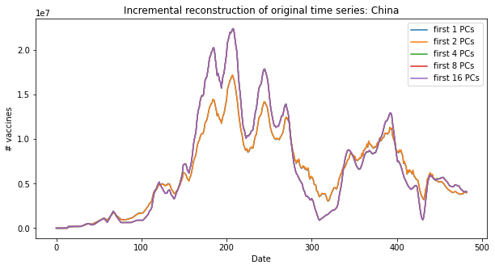

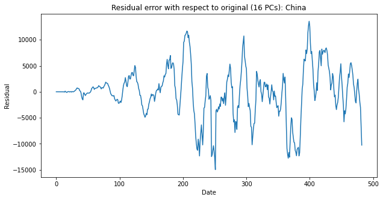

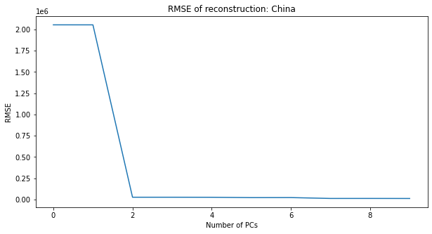

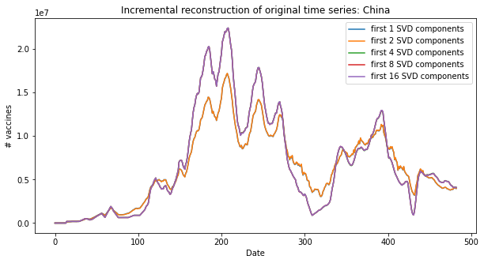

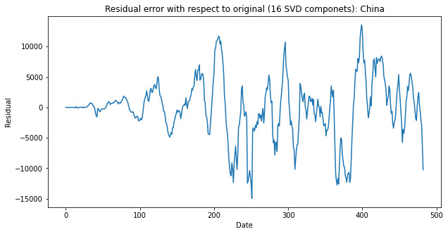

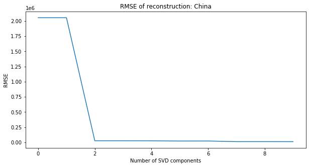

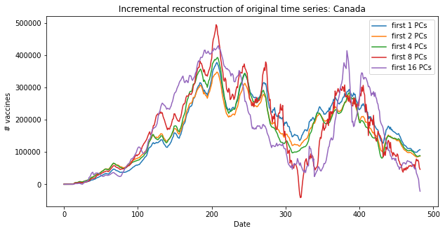

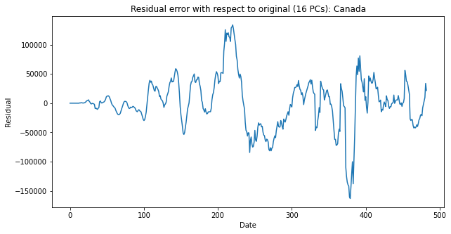

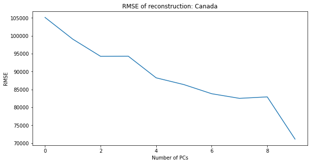

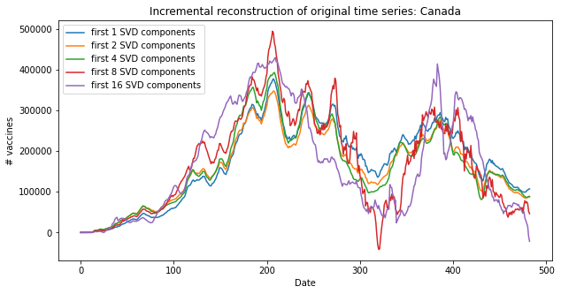

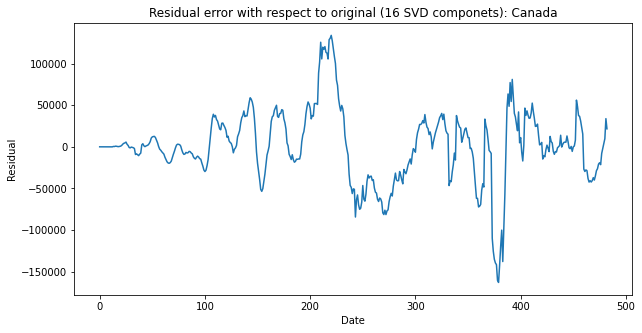

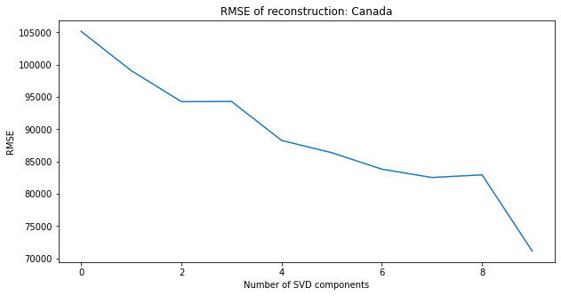

[6 more figures not shown]

```python
countries = ['China', 'Canada', 'United States']
for country in countries:
  plot_country_figures(cases_raw, country)
  plot_country_figures_svd(cases_raw, country)
```

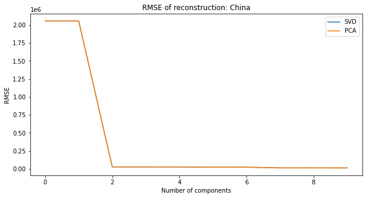

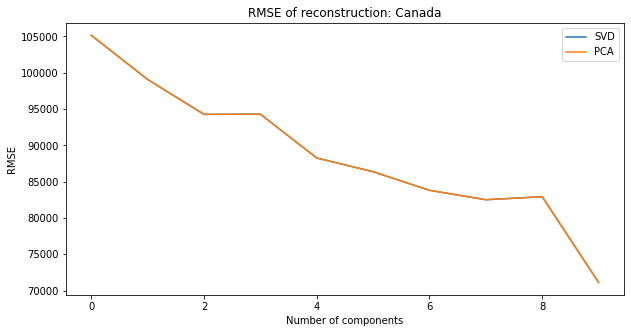

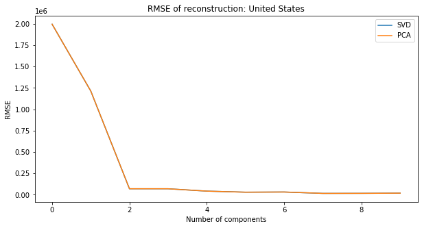

```python
# compare the results of PCA and SVD

def compare_PCA_SVD(countries, df_original, df_std): # compare the RMSE for PCA and SVD
  for country in countries:
    # SVD
    reconstructions_RMSE = []
    for num in range(1,11):
      scaler = StandardScaler()
      scaler.fit_transform(df_original) # fit scaler

      svd = TruncatedSVD(n_components=num)
      svd.fit_transform(df_std.values) # fit svd on standardized data
      projection = svd.transform(df_std.loc[country].values.reshape(1,-1))
      Reconx = svd.inverse_transform(projection)
      Reconx_origin = scaler.inverse_transform(Reconx.reshape(1,-1))
      Reconx_origin = Reconx_origin.reshape(483) # reshape for plotting

      reconstructions_RMSE.append(Reconx_origin)
    assert len(reconstructions_RMSE) == 10, "reconstructions_RMSE length mismatch!"

    rmse_list = []
    for item in reconstructions_RMSE:
      rmse = mean_squared_error(df_original.loc[country].values, item) ** 0.5 # calculate RMSE
      rmse_list.append(rmse)
    assert len(rmse_list) == 10, "RMSE length mismatch!"
    plt.plot(rmse_list, label = 'SVD')
    plt.title(f'RMSE of reconstruction: {country}')
    plt.xlabel('Number of components')
    plt.ylabel("RMSE")
    plt.legend()
    # PCA
    reconstructions_RMSE = []
    for num in range(1,11):
      eigenvector_select = eigenVectors[:, 0:num] # select PC
      assert eigenvector_select.shape == (483, num), "Wrong eigenvector shape"
      projection = np.dot(df_std.loc[country], eigenvector_select) #project on selected PCs
      ReconX = np.dot(projection, eigenvector_select.T) #reconstruction
      scaler = StandardScaler()
      scaler.fit_transform(df_original) # first fit and then inverse it
      Reconx_origin = scaler.inverse_transform(ReconX.reshape(1,-1))
      assert Reconx_origin.shape == (1,483), "reconstructed original data shape mismatch!"
      Reconx_origin = Reconx_origin.reshape(483) # reshape for plotting

      reconstructions_RMSE.append(Reconx_origin)
    assert len(reconstructions_RMSE) == 10, "reconstructions_RMSE length mismatch!"

    rmse_list = []
    for item in reconstructions_RMSE:
      rmse = mean_squared_error(df_original.loc[country].values, item) ** 0.5 # calculate RMSE
      rmse_list.append(rmse)
    assert len(rmse_list) == 10, "RMSE length mismatch!"
    plt.plot(rmse_list,label = 'PCA')
    plt.title(f'RMSE of reconstruction: {country}')
    plt.xlabel('Number of components')
    plt.ylabel("RMSE")
    plt.legend()
    plt.show()


compare_PCA_SVD(countries, cases_raw, cases_std)
```

# Part 5: Let's collect another dataset! [2 Marks]

Create another dataset similar to the one provided in your handout using the raw information on COVID deaths (not vaccinations) provided [here](https://datahub.io/core/covid-19#resource-time-series-19-covid-combined). **[1]**

Ans: The dataset used is countries-aggregated dataset.

You need to manipulate the data to organize it in the desired format (i.e., the same format that was in previous parts). You are free to use any tools you like, from Excel to Python!

In the end, you should have a new CSV file with more dates (features) compared to the provided dataset.

Upload your new dataset (in CSV format) to your colab notebook and repeat part 4. When analyzing Canada, you may use just Ontario. For China, you may use Beijing. **[1]**

Ans: see cell #17.

Don't forget to add your new CSV file to Quercus for reference. The code below helps you to upload your new CSV file to your colab session.

```python
# load train.csv to Google Colab
from google.colab import files
uploaded = files.upload()
```

```
Saving countries_deaths.csv to countries_deaths.csv
```

```python
### YOUR CODE HERE ###
# create another dataset from  countries-aggregated dataset, the code for preprocessing is:
'''
import pandas as pd
import numpy as np
rawdata = pd.read_csv('countries-aggregated_csv.csv')
rawdata = rawdata.drop(columns = ['Confirmed', 'Recovered'])
# get countries
indexs = rawdata.Country.values
countries = np.unique(indexs)
# get dates
columns = rawdata.Date.values
dates = np.unique(columns)

print(f'data shape should be: ({countries.shape[0]}, {dates.shape[0]})')
data_arr = np.empty((countries.shape[0], dates.shape[0]), int)

i = 0
for country in countries:
  j = 0
  for date in dates:
     try:
       data_arr[i][j] = int(rawdata.loc[(rawdata['Country'] == country) & (rawdata['Date'] == date)]['Deaths'])
       print("1")
     except:
       print("exception triggered")
       data_arr[i][j] = 0
     j += 1
  i += 1

deaths_raw = pd.DataFrame(data_arr, columns = dates, index = countries)
deaths_raw.to_csv('countries_deaths.csv', encoding='utf-8', index=False)

'''

deaths_raw = pd.read_csv('countries_deaths.csv')
deaths_raw.set_index('country', inplace=True)
deaths_raw
```

| country | 2020-01-22 | 2020-01-23 | 2020-01-24 | 2020-01-25 | 2020-01-26 | 2020-01-27 | 2020-01-28 | 2020-01-29 | 2020-01-30 | 2020-01-31 | ... | 2022-01-14 | 2022-01-15 | 2022-01-16 | 2022-01-17 | 2022-01-18 | 2022-01-19 | 2022-01-20 | 2022-01-21 | 2022-01-22 | 2022-01-23 |
| --- | --- | --- | --- | --- | --- | --- | --- | --- | --- | --- | --- | --- | --- | --- | --- | --- | --- | --- | --- | --- | --- |
| Afghanistan | 0 | 0 | 0 | 0 | 0 | 0 | 0 | 0 | 0 | 0 | ... | 7376 | 7378 | 7379 | 7381 | 7383 | 7386 | 7386 | 7390 | 7390 | 7393 |
| Albania | 0 | 0 | 0 | 0 | 0 | 0 | 0 | 0 | 0 | 0 | ... | 3262 | 3265 | 3269 | 3271 | 3277 | 3283 | 3286 | 3292 | 3297 | 3305 |
| Algeria | 0 | 0 | 0 | 0 | 0 | 0 | 0 | 0 | 0 | 0 | ... | 6393 | 6404 | 6412 | 6423 | 6435 | 6443 | 6453 | 6468 | 6481 | 6495 |
| Andorra | 0 | 0 | 0 | 0 | 0 | 0 | 0 | 0 | 0 | 0 | ... | 142 | 142 | 142 | 142 | 142 | 142 | 144 | 144 | 144 | 144 |
| Angola | 0 | 0 | 0 | 0 | 0 | 0 | 0 | 0 | 0 | 0 | ... | 1852 | 1857 | 1863 | 1866 | 1870 | 1877 | 1881 | 1884 | 1886 | 1888 |
| ... | ... | ... | ... | ... | ... | ... | ... | ... | ... | ... | ... | ... | ... | ... | ... | ... | ... | ... | ... | ... | ... |
| Vietnam | 0 | 0 | 0 | 0 | 0 | 0 | 0 | 0 | 0 | 0 | ... | 35341 | 35480 | 35609 | 35609 | 35972 | 36114 | 36266 | 36443 | 36596 | 36719 |
| West Bank and Gaza | 0 | 0 | 0 | 0 | 0 | 0 | 0 | 0 | 0 | 0 | ... | 5005 | 5005 | 5005 | 5019 | 5027 | 5031 | 5036 | 5042 | 5042 | 5042 |
| Yemen | 0 | 0 | 0 | 0 | 0 | 0 | 0 | 0 | 0 | 0 | ... | 1988 | 1988 | 1990 | 1991 | 1992 | 1994 | 1995 | 1995 | 1995 | 1995 |
| Zambia | 0 | 0 | 0 | 0 | 0 | 0 | 0 | 0 | 0 | 0 | ... | 3844 | 3852 | 3860 | 3866 | 3873 | 3877 | 3879 | 3885 | 3890 | 3895 |
| Zimbabwe | 0 | 0 | 0 | 0 | 0 | 0 | 0 | 0 | 0 | 0 | ... | 5238 | 5238 | 5247 | 5258 | 5258 | 5266 | 5276 | 5288 | 5292 | 5294 |

196 rows × 733 columns

```python
deaths_std = deaths_raw.copy()
std_values = StandardScaler().fit_transform(deaths_std.values) # standardize data
deaths_std = pd.DataFrame(std_values, columns = deaths_std.columns, index = deaths_std.index) #create dataset

data_values = deaths_std.values
cov_matrix = np.cov(data_values.T)
assert cov_matrix.shape == (733, 733), "ERROR: cov matrix shape mismatch."

# get eigenvalues/vectors
eigenValues, eigenVectors = get_sorted_eigen(cov_matrix)

args = (-eigenValues).argsort()
eigenValues = eigenValues[args]
eigenVectors = eigenVectors[:, args]


def plot_country_figures_part5(original_df, country_name):
  #original time-series
  deaths_raw.loc[country_name].plot()
  plt.xlabel('Date')
  plt.ylabel('# deaths')
  plt.title(f'Original time series: {country_name}')
  plt.show()
  #The incremental reconstruction of the original (not standardized) time-series
  num_pcs = [1,2,4,8,16]
  reconstructions =[]
  for num in num_pcs:
    eigenvector_select = eigenVectors[:, 0:num] # select PC
    assert eigenvector_select.shape == (733, num), "Wrong eigenvector shape"
    projection = np.dot(deaths_std.loc[country_name], eigenvector_select) #project on selected PCs
    ReconX = np.dot(projection, eigenvector_select.T) #reconstruction
    scaler = StandardScaler()
    scaler.fit_transform(original_df) # first fit and then inverse it
    Reconx_origin = scaler.inverse_transform(ReconX.reshape(1,-1))
    assert Reconx_origin.shape == (1,733), "reconstructed original data shape mismatch!"
    Reconx_origin = Reconx_origin.reshape(733) # reshape for plotting

    reconstructions.append(Reconx_origin)
  # plot the time-series
  i = 0
  for num in num_pcs:
    reconstruction = reconstructions[i]
    plt.plot(reconstruction, label=f'first {num} PCs')
    plt.title(f'Incremental reconstruction of original time series: {country_name}')
    plt.xlabel('Date')
    plt.ylabel('# deaths')
    plt.legend()
    i += 1
  plt.show()

  # find the residual error for your best reconstruction (PC16) with respect to the original time-series.
  Reconx_origin_16 = reconstructions[-1]
  residual = original_df.loc[country_name].values - Reconx_origin_16
  plt.plot(residual)
  plt.title(f'Residual error with respect to original (16 PCs): {country_name}')
  plt.xlabel('Date')
  plt.ylabel("Residual")
  plt.show()

  #The RMSE of the reconstruction as a function of the number of included components
  reconstructions_RMSE = []
  for num in range(1,11):
    eigenvector_select = eigenVectors[:, 0:num] # select PC
    assert eigenvector_select.shape == (733, num), "Wrong eigenvector shape"
    projection = np.dot(deaths_std.loc[country_name], eigenvector_select) #project on selected PCs
    ReconX = np.dot(projection, eigenvector_select.T) #reconstruction
    scaler = StandardScaler()
    scaler.fit_transform(original_df) # first fit and then inverse it
    Reconx_origin = scaler.inverse_transform(ReconX.reshape(1,-1))
    assert Reconx_origin.shape == (1,733), "reconstructed original data shape mismatch!"
    Reconx_origin = Reconx_origin.reshape(733) # reshape for plotting

    reconstructions_RMSE.append(Reconx_origin)
  assert len(reconstructions_RMSE) == 10, "reconstructions_RMSE length mismatch!"

  rmse_list = []
  for item in reconstructions_RMSE:
    rmse = mean_squared_error(original_df.loc[country_name].values, item) ** 0.5 # calculate RMSE
    rmse_list.append(rmse)
  assert len(rmse_list) == 10, "RMSE length mismatch!"
  plt.plot(rmse_list)
  plt.title(f'RMSE of reconstruction: {country_name}')
  plt.xlabel('Number of PCs')
  plt.ylabel("RMSE")
  plt.show()
```

```python
def plot_country_figures_svd_part5(original_df, country_name):
  #original time-series
  deaths_raw.loc[country_name].plot()
  plt.xlabel('Date')
  plt.ylabel('# deaths')
  plt.title(f'Original time series: {country_name}')
  plt.show()
  #The incremental reconstruction of the original (not standardized) time-series
  num_pcs = [1,2,4,8,16]
  reconstructions =[]
  for num in num_pcs:
    # use SVD
    scaler = StandardScaler()
    scaler.fit_transform(original_df) # fit scaler

    svd = TruncatedSVD(n_components=num)
    svd.fit_transform(deaths_std.values) # fit svd on standardized data
    projection = svd.transform(deaths_std.loc[country_name].values.reshape(1,-1))
    Reconx = svd.inverse_transform(projection)
    Reconx_origin = scaler.inverse_transform(Reconx.reshape(1,-1))
    Reconx_origin = Reconx_origin.reshape(733) # reshape for plotting
    reconstructions.append(Reconx_origin)
  # plot the time-series
  i = 0
  for num in num_pcs:
    reconstruction = reconstructions[i]
    plt.plot(reconstruction, label=f'first {num} SVD components')
    plt.title(f'Incremental reconstruction of original time series: {country_name}')
    plt.xlabel('Date')
    plt.ylabel('# deaths')
    plt.legend()
    i += 1
  plt.show()

  # find the residual error for your best reconstruction (16) with respect to the original time-series.
  Reconx_origin_16 = reconstructions[-1]
  residual = original_df.loc[country_name].values - Reconx_origin_16
  plt.plot(residual)
  plt.title(f'Residual error with respect to original (16 SVD components): {country_name}')
  plt.xlabel('Date')
  plt.ylabel("Residual")
  plt.show()

  #The RMSE of the reconstruction as a function of the number of included components
  reconstructions_RMSE = []
  for num in range(1,11):
    # use SVD
    scaler = StandardScaler()
    scaler.fit_transform(original_df) # fit scaler

    svd = TruncatedSVD(n_components=num)
    svd.fit_transform(deaths_std.values) # fit svd on standardized data
    projection = svd.transform(deaths_std.loc[country_name].values.reshape(1,-1))
    Reconx = svd.inverse_transform(projection)
    Reconx_origin = scaler.inverse_transform(Reconx.reshape(1,-1))
    Reconx_origin = Reconx_origin.reshape(733) # reshape for plotting

    reconstructions_RMSE.append(Reconx_origin)
  assert len(reconstructions_RMSE) == 10, "reconstructions_RMSE length mismatch!"

  rmse_list = []
  for item in reconstructions_RMSE:
    rmse = mean_squared_error(original_df.loc[country_name].values, item) ** 0.5 # calculate RMSE
    rmse_list.append(rmse)
  assert len(rmse_list) == 10, "RMSE length mismatch!"
  plt.plot(rmse_list)
  plt.title(f'RMSE of reconstruction: {country_name}')
  plt.xlabel('Number of SVD components')
  plt.ylabel("RMSE")
  plt.show()
```

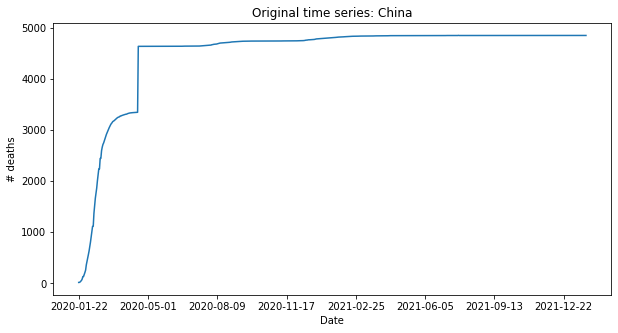

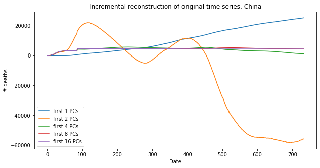

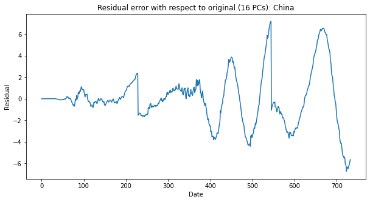

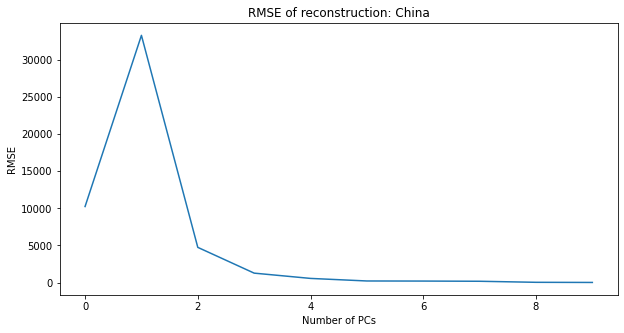

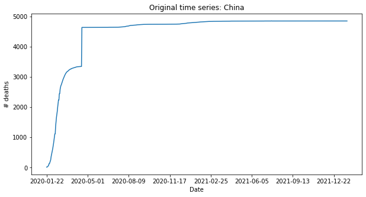

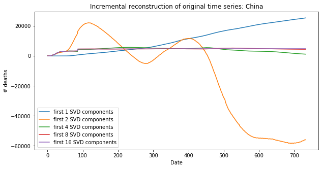

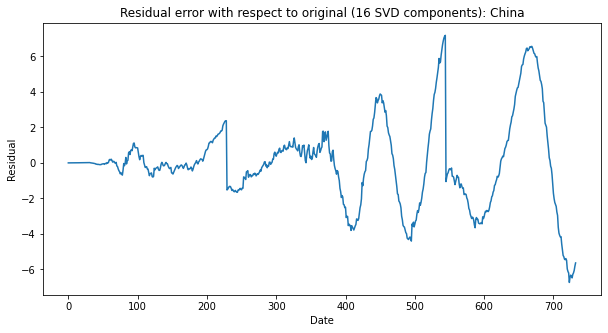

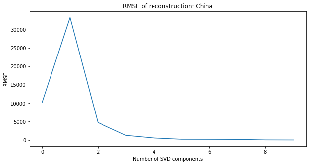

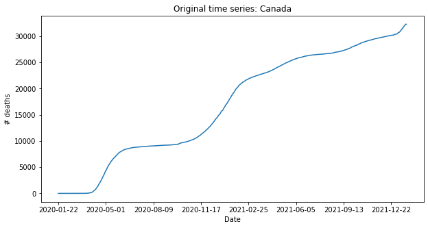

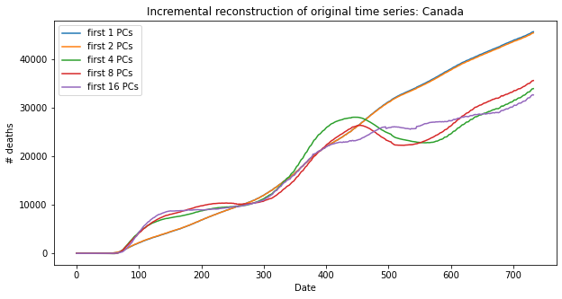

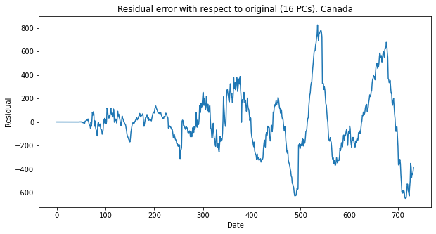

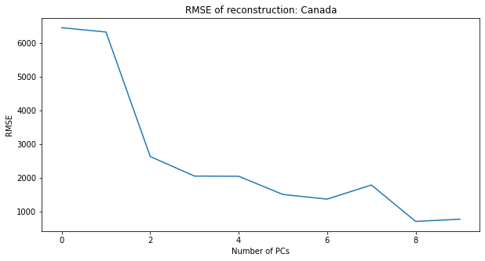

[12 more figures not shown]

```python
countries = ['China', 'Canada', 'US']
for country in countries:
  plot_country_figures_part5(deaths_raw, country)
  plot_country_figures_svd_part5(deaths_raw, country)
```

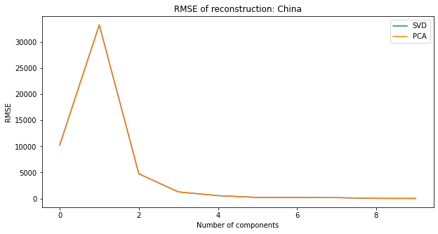

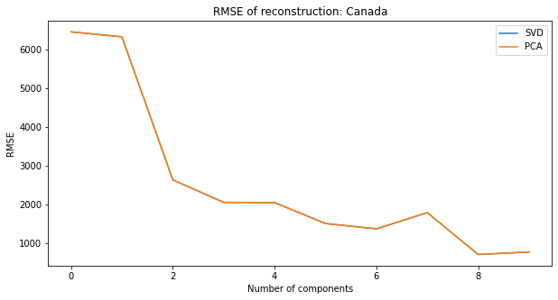

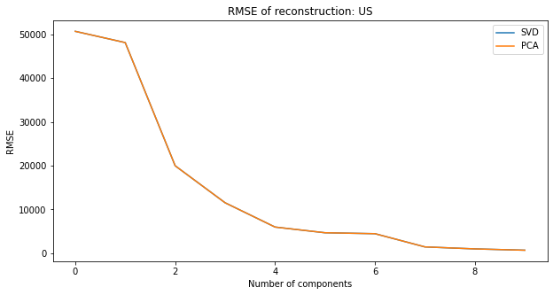

```python
# compare the results of PCA and SVD

def compare_PCA_SVD(countries, df_original, df_std): # compare the RMSE for PCA and SVD
  for country in countries:
    # SVD
    reconstructions_RMSE = []
    for num in range(1,11):
      scaler = StandardScaler()
      scaler.fit_transform(df_original) # fit scaler

      svd = TruncatedSVD(n_components=num)
      svd.fit_transform(df_std.values) # fit svd on standardized data
      projection = svd.transform(df_std.loc[country].values.reshape(1,-1))
      Reconx = svd.inverse_transform(projection)
      Reconx_origin = scaler.inverse_transform(Reconx.reshape(1,-1))
      Reconx_origin = Reconx_origin.reshape(733) # reshape for plotting

      reconstructions_RMSE.append(Reconx_origin)
    assert len(reconstructions_RMSE) == 10, "reconstructions_RMSE length mismatch!"

    rmse_list = []
    for item in reconstructions_RMSE:
      rmse = mean_squared_error(df_original.loc[country].values, item) ** 0.5 # calculate RMSE
      rmse_list.append(rmse)
    assert len(rmse_list) == 10, "RMSE length mismatch!"
    plt.plot(rmse_list, label = 'SVD')
    plt.title(f'RMSE of reconstruction: {country}')
    plt.xlabel('Number of components')
    plt.ylabel("RMSE")
    plt.legend()
    # PCA
    reconstructions_RMSE = []
    for num in range(1,11):
      eigenvector_select = eigenVectors[:, 0:num] # select PC
      assert eigenvector_select.shape == (733, num), "Wrong eigenvector shape"
      projection = np.dot(df_std.loc[country], eigenvector_select) #project on selected PCs
      ReconX = np.dot(projection, eigenvector_select.T) #reconstruction
      scaler = StandardScaler()
      scaler.fit_transform(df_original) # first fit and then inverse it
      Reconx_origin = scaler.inverse_transform(ReconX.reshape(1,-1))
      assert Reconx_origin.shape == (1,733), "reconstructed original data shape mismatch!"
      Reconx_origin = Reconx_origin.reshape(733) # reshape for plotting

      reconstructions_RMSE.append(Reconx_origin)
    assert len(reconstructions_RMSE) == 10, "reconstructions_RMSE length mismatch!"

    rmse_list = []
    for item in reconstructions_RMSE:
      rmse = mean_squared_error(df_original.loc[country].values, item) ** 0.5 # calculate RMSE
      rmse_list.append(rmse)
    assert len(rmse_list) == 10, "RMSE length mismatch!"
    plt.plot(rmse_list,label = 'PCA')
    plt.title(f'RMSE of reconstruction: {country}')
    plt.xlabel('Number of components')
    plt.ylabel("RMSE")
    plt.legend()
    plt.show()


compare_PCA_SVD(countries, deaths_raw, deaths_std)
```

# References

Understanding PCA and SVD:

1. https://towardsdatascience.com/pca-and-svd-explained-with-numpy-5d13b0d2a4d8
2. https://stats.stackexchange.com/questions/134282/relationship-between-svd-and-pca-how-to-use-svd-to-perform-pca
3. https://stats.stackexchange.com/questions/2691/making-sense-of-principal-component-analysis-eigenvectors-eigenvalues
4. https://hadrienj.github.io/posts/Deep-Learning-Book-Series-2.8-Singular-Value-Decomposition/

PCA:

1. Snippets from: https://plot.ly/ipython-notebooks/principal-component-analysis/
2. https://www.value-at-risk.net/principal-component-analysis/

Covid Data:

1. https://www.worldometers.info/coronavirus/
2. https://datahub.io/core/covid-19#resource-time-series-19-covid-combined